# Predicting Tree Mortality with XGBoost

# Background on Data: Tree Mortality

In the past decade, forest fires have increased due to climate change and fire suppression policies, with bark beetle infestations playing a notable role. Prescribed burns are used to reduce fuel and lower the risk of more intense fires while improving overall forest health. Bark beetles can lead to increased fire risk and negatively impact forest health by killing trees and reducing carbon absorption. The US Forestry Service’s FTM database compiles data on tree mortality from both prescribed and naturally occurring fires. A subset of this database includes tree descriptors, health status, and beetle species presence over a decade. This information can be used as input in supervised learning models to predict if a given tree will survive up to three years based on its current state.

The variables presented here primiarly quantify aspects of a trees defense capabilites, extent of fire injury, and biotic stress.

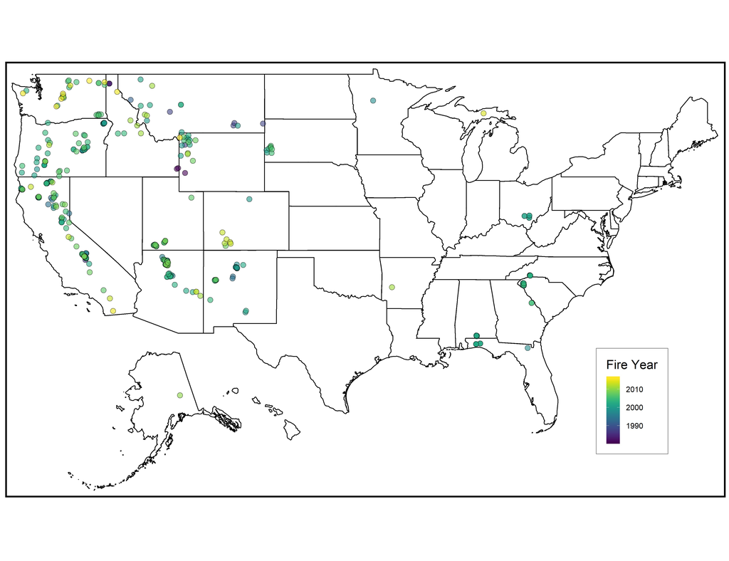

Locations

### Many variables are missing across many tree records. Only features with 50% or more of all measurements recorded are used as input variables. Numerical features are imputed with the mean and categorical variables are encoded.

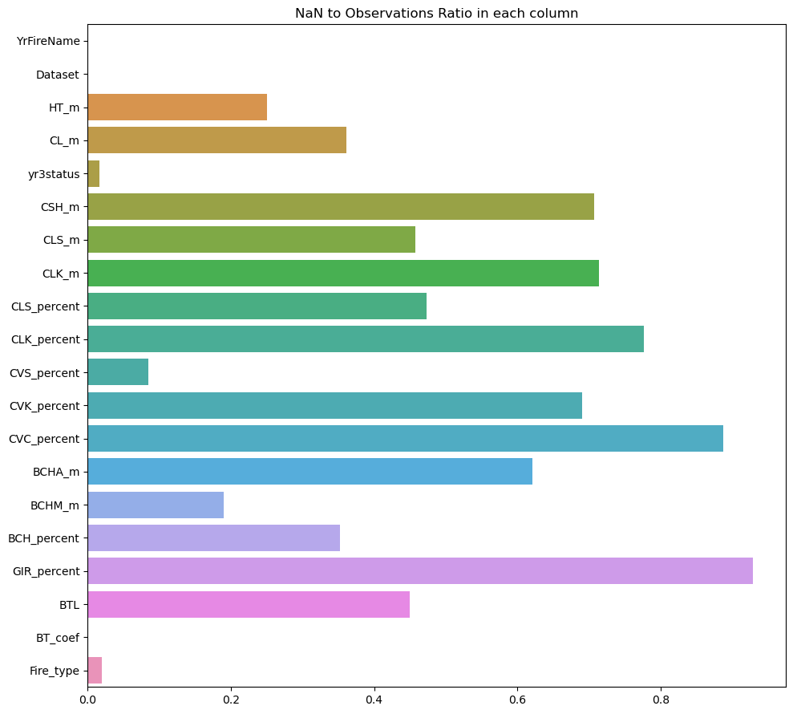

|  | YrFireName | Dataset | HT_m | CL_m | yr3status | CLS_m | CLS_percent | CVS_percent | BCHM_m | BCH_percent | BTL | BT_coef | Fire_type_RX | Fire_type_WILD |
| --- | --- | --- | --- | --- | --- | --- | --- | --- | --- | --- | --- | --- | --- | --- |
| 565 | 2003 - Griff | Progar | 41.76 | 35.05 | 1.0 | 4.27 | 12.0 | 10.0 | 6.71 | 16.0 | 1.0 | 0.047 | 0 | 1 |
| 566 | 2003 - Griff | Progar | 12.80 | 7.62 | 0.0 | 0.30 | 4.0 | 0.0 | 0.08 | 1.0 | 0.0 | 0.047 | 0 | 1 |
| 567 | 2003 - Griff | Progar | 34.75 | 25.91 | 1.0 | 5.49 | 21.0 | 5.0 | 1.83 | 5.0 | 0.0 | 0.047 | 0 | 1 |
| 568 | 2003 - Griff | Progar | 23.16 | 8.84 | 0.0 | 0.00 | 0.0 | 0.0 | 0.30 | 1.0 | 0.0 | 0.047 | 0 | 1 |
| 569 | 2003 - Griff | Progar | 26.21 | 10.97 | 1.0 | 0.00 | 0.0 | 0.0 | 1.22 | 5.0 | 0.0 | 0.047 | 0 | 1 |

# Model Creation

```python
from xgboost import XGBClassifier

#Hyperparameter Tunining with Grid-Search
def get_best_XGB_model(X_train,y_train,params):
    clf = XGBClassifier(seed = seed)
    gcv = GridSearchCV(estimator=clf, param_grid=params, scoring = 'roc_auc')
    gcv.fit(X_train, y_train)
    model = gcv.best_estimator_
    return model

#note: sklearn.metrics.confusion_matrix uses class in sorted order so 0,1 --> Dead, Alive
def evaluate_classifier(clf, X_train, y_train, X_test, y_test):
    clf.fit(X_train, y_train)
    y_pred = clf.predict(X_test)
    confusion_mat = confusion_matrix(y_test, y_pred)
    accuracy = accuracy_score(y_test, y_pred)
    fpr, tpr, thresholds = roc_curve(y_test, y_pred)
    auc = roc_auc_score(y_test, y_pred)
    disp = ConfusionMatrixDisplay(confusion_mat, display_labels=['Dead','Alive'])
    return accuracy, disp, fpr, tpr, auc


X = FTM_Select.drop(columns=['yr3status','YrFireName','Dataset'])
y = FTM_Select['yr3status']

X_train, X_test, y_train, y_test = train_test_split(X, y, test_size=0.2, random_state=42)

params_XGB = {'max_depth': range (2, 10, 1),
    'n_estimators': range(60, 220, 40),
    'learning_rate': [0.1, 0.01, 0.05]}


clf = get_best_XGB_model(X_train,y_train,params_XGB)

accuracy, disp, fpr, tpr, auc = evaluate_classifier(clf, X_train, y_train, X_test, y_test)
```

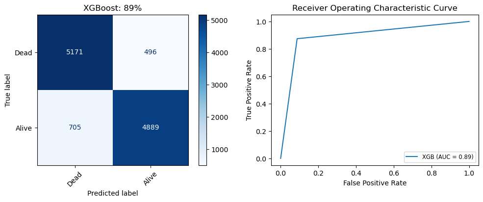

```python
import matplotlib.pyplot as plt

fig, axs = plt.subplots(1, 2, figsize=(12, 4))


disp.plot(cmap=plt.cm.Blues, xticks_rotation=45, ax=axs[0])
axs[0].set_title("{}: {:.0f}%".format("XGBoost", accuracy * 100))

name = 'XGB'
label = f'{name} (AUC = %0.2f)' % auc
axs[1].plot(fpr, tpr, label=label)
axs[1].set_xlabel('False Positive Rate')
axs[1].set_ylabel('True Positive Rate')
axs[1].set_title('Receiver Operating Characteristic Curve')
axs[1].legend(loc="lower right", fontsize='small')

plt.show()
```

```python
FTM_Select['yr3status'].value_counts()
```

```
1.0    28250
0.0    28055
Name: yr3status, dtype: int64
```

# Conclusion

Model performance is comparable to the best performing logistic models in recent [publication](https://fireecology.springeropen.com/articles/10.1186/s42408-020-00082-0) and varies more significantly between species.

# References, Links to Data

[FTM Data](https://www.fs.usda.gov/rds/archive/catalog/RDS-2020-0001-2)

[Data Descriptor](https://www.nature.com/articles/s41597-020-0522-7)